# Trabajo Practico Final - Gonzalo Machin

## Evolucion de la Siniestralidad Urbana en Uruguay

### Periodo 2013 - 2021

El objetivo de este trabajo es estudiar la siniestralidad urbana en Uruguay, entender cuales son los patrones que afectan a esta y que lugares del pais son los que presentan una mayor inseguridad vial, ademas de entender la tendencia que ha tenido en este periodo.

Como pregunta se plantea estudiar la evolucion de la siniestralidad urbana en el pais y ver la evolucion de la misma en las ciudades del pais con mas de 5000 habitantes. Cuales son las ciudades con mas siniestros y cuales han logrado reducir en mayor medida los siniestros en el año 2021?

# Clear

```r
rm(list = ls())

gc()
```

```
##          used (Mb) gc trigger (Mb) max used (Mb)
## Ncells 493821 26.4    1088948 58.2   643937 34.4
## Vcells 874917  6.7    8388608 64.0  1649639 12.6
```

# Librarys

```r
library(tidyverse)
library(lubridate)
library(sf)
```

```r
library(stringr)
library(mapview)
library(ggspatial)
library(units)
library(patchwork)
library(geofacet)
source("get_data_functions.R")
library(here)
library(hexbin)
library(rayshader)
library(ggrepel)
library(leaflet)
```

### Datasets

Dataset sobre siniestros y personas afectadas extraido de la pagina de UNASEV

Zonas Censales y poblacion pueden ser accedidos atraves de la pagina del Instituto Nacional de Estadistica (INE)

```r
Siniestros <- get_siniestros()
Personas <- get_personas()
Departamentos <- read_sf("Departamentos/departamentos_Polygons.shp")
zonas_censales <- read_sf("zonas_censales/ine_seg_11.shp")
poblacion <- read.csv("zonas_censales/personas_por_zona.csv")
localidades <- read_sf("localidades/localidades_uruguay-polygon.shp")
```

Datasets Utilizados:

Siniestros: Registros de todos los siniestros de transito en el pais durante el periodo 2013 y marzo 2022

Personas: Registros de todas las personas afectadas en siniestros de transito durante el periodo 2013 y marzo 2022

Departamentos: Shapefile con los limites departamentales

Zonas Censales: Shapefile con las zonas censales correspondientes al ultimo censo nacional en 2011

Poblacion: Poblacion por zona censal

Localidades: Shapefile de las localidades de Uruguay

## Poblacion y Zonas Censales

### Limpieza de Datos y Armado de informacion a Analizar

Para cruzar los datasets de poblacion y zonas censales es necesario crear una variable unica por segmento censal, dado que el shp de zonas censales no incluye la informacion de la poblacion

```r
poblacion <- poblacion %>%
  mutate(CODSEG = ((DPTO*100000) + (SECC*1000) + SEGM)) %>%
  select(CODSEG,Total)
```

```r
zonas_censales <- zonas_censales %>%
  left_join(poblacion,by = "CODSEG")

sf_use_s2(FALSE)
```

```
## Spherical geometry (s2) switched off
```

```r
zonas_censales <- zonas_censales %>%
  mutate_all(~replace(., is.na(.), 0)) %>%
  mutate(Zonificacion = if_else(NOMBLOC == "RURAL","RURAL","URBANO")) %>%
  st_set_crs(32721) %>%
  st_transform(4326) %>%
  mutate(Area_km2 = units::set_units(st_area(zonas_censales), km^2)) %>%
  mutate(Area_km2 = sub(" [km^2].*","",Area_km2)) %>%
  mutate(Area_km2 = as.numeric(Area_km2)) %>%
  mutate(Densidad = Total/Area_km2)
```

### Distribucion de la poblacion nacional

En la siguiente infografia se puede apreciar la poca superficie urbana que tiene el pais, pero tambien la concentracion urbana que tiene:

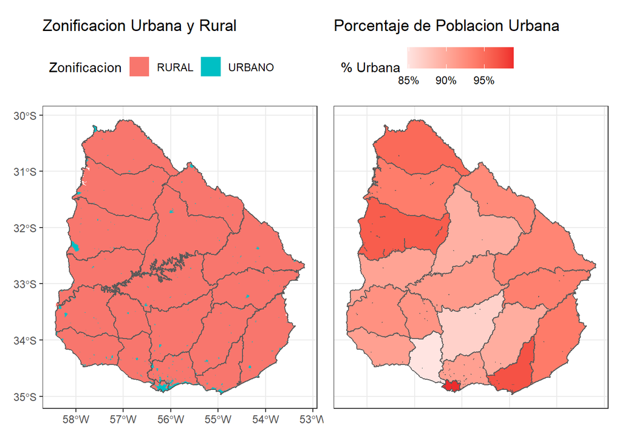

```r
options(scipen=1000000)

gg_zonificacion <- ggplot()+
  geom_sf(data = zonas_censales,aes(fill = Zonificacion), colour = NA)+
  geom_sf(data = Departamentos,fill = NA)+
  labs(title = "Zonificacion Urbana y Rural")+
  theme_bw()+
  theme(legend.position = "top",
        legend.justification = "left")

gg_urbana_depto <- ggplot()+
  geom_sf(data = depto,aes(fill = Porcentaje_urbano))+
  labs(title = "Porcentaje de Poblacion Urbana",
       fill = "% Urbana")+
  scale_fill_gradient(low="mistyrose1", high="firebrick2",labels = scales::percent)+
  theme_bw()+
  theme(axis.text.x=element_blank(),
        axis.text.y=element_blank(),
        axis.ticks=element_blank())+
   theme(legend.position = "top",
        legend.justification = "left")

gg_zonificacion | gg_urbana_depto
```

Como se puede apreciar Montevideo y Maldonado son los departamentos con mayor porcentaje de poblacion viviendo en centro urbanos, mientras que ningun departamento del pais se ubica por debajo del 85% de la poblacion viviendo en centros urbanos

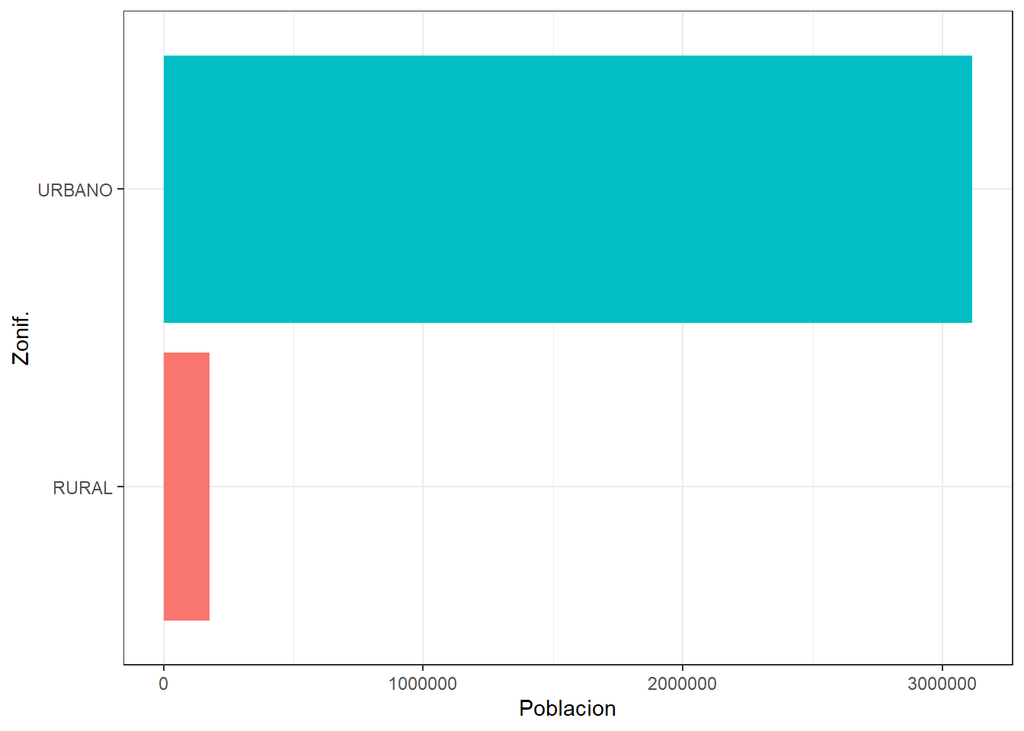

```r
ggplot(zonas_censales %>%
         st_set_geometry(NULL) %>%
         group_by(Zonificacion) %>%
         summarise(Total = sum(Total)))+
  geom_bar(aes(y=Zonificacion,weight = Total,fill = Zonificacion))+
  labs(y = "Zonif.",
       x = "Poblacion")+
  theme_bw()+
  theme(legend.position = "none")
```

Planteando la hipotesis de que la poblacion uruguaya habita predominantemente en las ciudades es necesario investigar como la poblacion se ve afectada por la siniestralidad del transito, dado que este patron de ubicacion de la poblacion.

## Siniestros

Primero corregiriemos y filtraremos nuestro dataset para usarlo a posteriri para hacer los calculos pertinentes

```r
Siniestros  <- Siniestros %>%
  mutate(anio = as.numeric(anio)) %>%
  filter(anio <= 2021)
```

```r
Siniestros <- st_join(Siniestros,zonas_censales)
Siniestros <- st_join(Siniestros,Departamentos)
```

Observamos el total de siniestros por departamento tanto en zonas rurales como en zonas urbanas

```r
siniestros_depto_porcentaje <- Siniestros %>%
  st_set_geometry(NULL) %>%
  group_by(NOMBDEPTO,
           Zonificacion) %>%
  summarise(Total = sum(Total)) %>%
  pivot_wider(names_from = Zonificacion,values_from = Total) %>%
  mutate(Siniestros = URBANO+RURAL) %>%
  mutate(Porcentaje_urbano = URBANO/(URBANO+RURAL)) %>%
  filter(!is.na(NOMBDEPTO)) %>%
  select(-'NA')

depto <- left_join(depto,siniestros_depto_porcentaje,by = "NOMBDEPTO")
```

```r
mygrid <- data.frame(
  code = c(1, 2, 3, 4, 5, 6, 7, 8, 9, 10, 11, 12, 13, 14, 15, 16, 17, 18, 19),
  name = c("Artigas", "Salto", "Rivera", "Cerro Largo", "Paysandu", "Tacuarembo", "Treinta y tres", "Durazno", "Rio Negro", "Rocha", "Florida", "Lavalleja", "Flores", "Soriano", "Canelones", "San Jose", "Colonia", "Maldonado", "Montevideo"),
  row = c(1, 2, 2, 2, 3, 3, 3, 4, 4, 4, 4, 5, 5, 5, 5, 6, 6, 6, 6),
  col = c(1, 1, 2, 3, 1, 2, 3, 2, 1, 4, 3, 4, 2, 1, 3, 2, 1, 4, 3),
  stringsAsFactors = FALSE
)
```

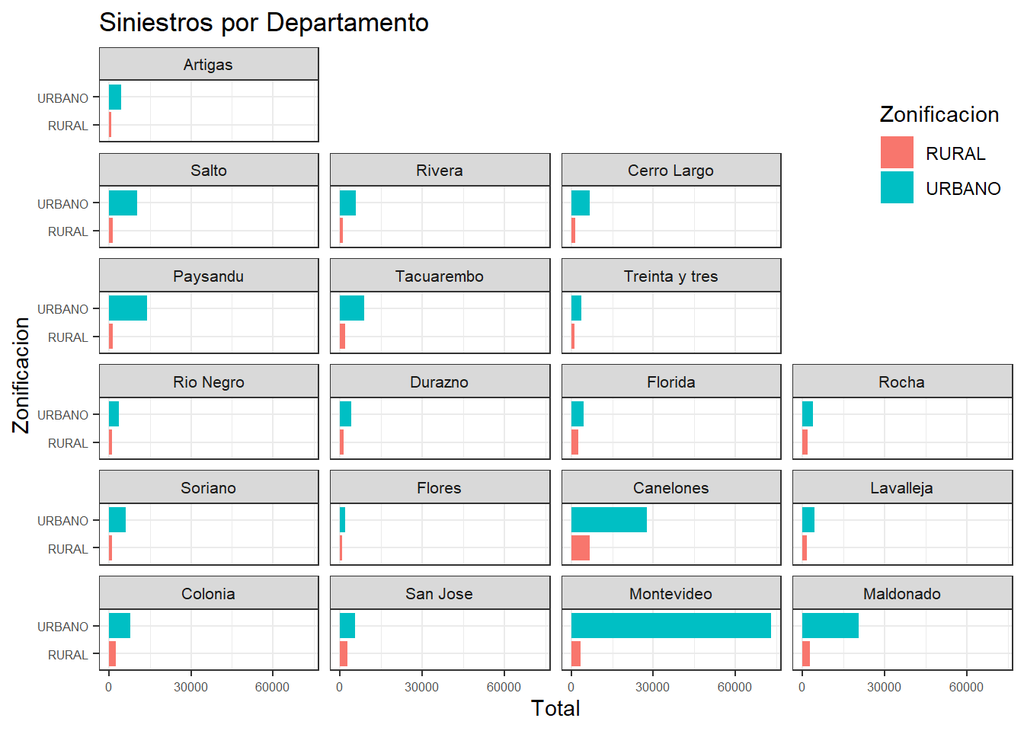

```r
ggplot(Siniestros %>%
  st_set_geometry(NULL) %>%
  group_by(admlnm,
           Zonificacion) %>%
  summarise(Total = n()) %>%
  filter(!is.na(admlnm),
         !is.na(Zonificacion)))+
  geom_bar(aes(y=Zonificacion,weight = Total,fill = Zonificacion))+
  scale_x_continuous(breaks = seq(0,60000,30000))+
  labs(title = "Siniestros por Departamento",
       x = "Total")+
  facet_geo(~admlnm,grid = mygrid)+
  theme_bw()+
  theme(axis.text = element_text(size = 6))+
  theme(strip.text.x = element_text(size = 8))+
  theme(legend.position = c(1, 0.77), legend.justification = c(1, 0))
```

Se puede apreciar que montevideo tambien es el departamento con mayor cantidad de siniestros, dado que esta cantidad esta altamente correlacionada con la poblacion del departamento.

Debajo se puede apreciar la relacion de cuantos siniestros son es areas urbanas por departamento.

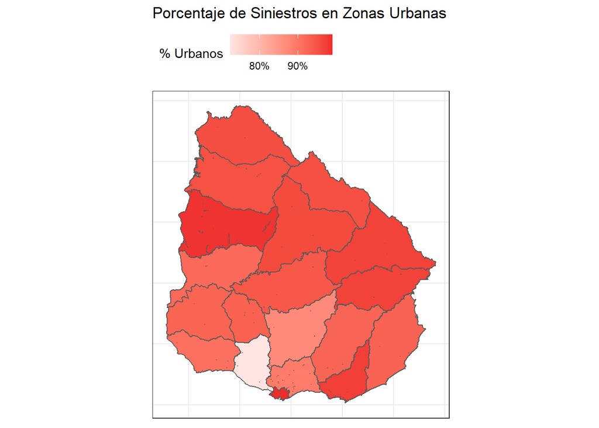

```r
ggplot()+
  geom_sf(data = depto,aes(fill = Porcentaje_urbano.y))+
  labs(title = "Porcentaje de Siniestros en Zonas Urbanas",
       fill = "% Urbanos")+
  scale_fill_gradient(low="mistyrose1", high="firebrick2",labels = scales::percent)+
  theme_bw()+
  theme(axis.text.x=element_blank(),
        axis.text.y=element_blank(),
        axis.ticks=element_blank())+
   theme(legend.position = "top",
        legend.justification = "left")
```

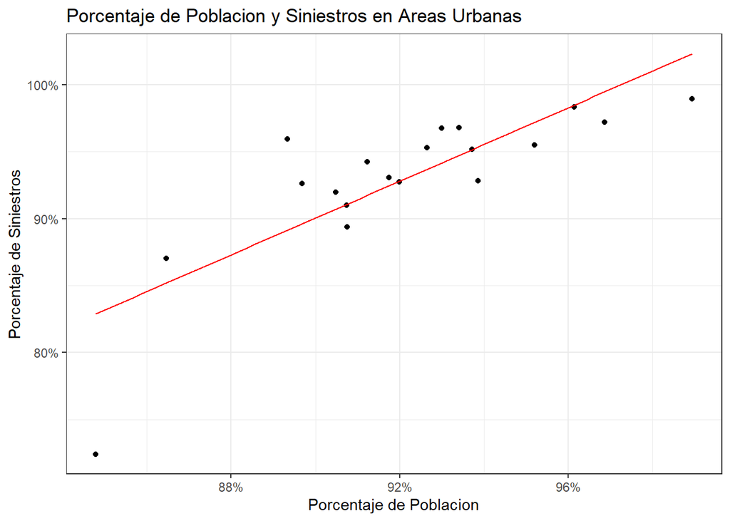

```r
ggplot(depto,aes(x=Porcentaje_urbano.x,y=Porcentaje_urbano.y))+
  geom_point()+
  geom_smooth(method=lm, se=FALSE, col='red', size=0.5)+
  labs(title = "Porcentaje de Poblacion y Siniestros en Areas Urbanas",
       y= "Porcentaje de Siniestros",
       x="Porcentaje de Poblacion")+
  scale_x_continuous(labels = scales::percent)+
  scale_y_continuous(labels = scales::percent)+
  theme_bw()
```

Evolucion de los Siniestros en entronos rurales y urbanos

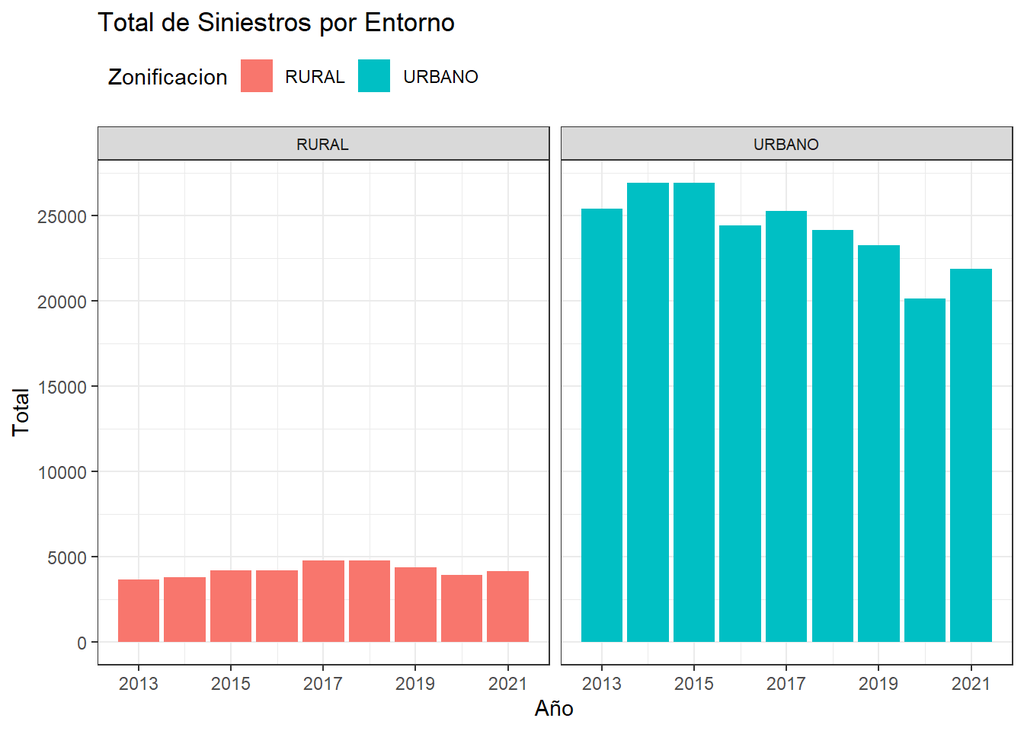

```r
ggplot(Siniestros %>%
         group_by(anio,
                  Zonificacion) %>%
         summarise(Total = n()) %>%
         filter(!is.na(Zonificacion)))+
  geom_bar(aes(x=anio,weight=Total,fill=Zonificacion))+
  labs(title = "Total de Siniestros por Entorno",
       x = "Año",
       y = "Total")+
  facet_grid(~Zonificacion)+
  scale_x_continuous(breaks = seq(2013,2021,2))+
  scale_y_continuous(breaks = seq(0,25000,5000))+
  theme_bw()+
  theme(strip.text.x = element_text(size = 8))+
  theme(legend.position = "top",
        legend.justification = "left")
```

Los picos de siniestros en los ultimos 8 años se dan en años distintos, siendo 2014/5 para los urbanos y 2017/8 para los siniestros en zonas rurales, esta es una tendencia intersante en especial para entornos urbanos habla de una mejora favorable en la siniestralidad, acompañado de un pico muy bajo en 2020 gracias a la pandemia.

Mientras que en el ultimo año 2021 se observo un leve crecimiento en relacion al año previo pero aun no se puede concluir nada hasta no tener los datos actualizados al año 2022.

A continuacion se investigara que centros poblados tienen mayores indicadores de siniestralidad urbana y se observara la tendencia en estos.

A prtir de este punto se trabajara con el total de siniestros cada 10.00 habitantes y tambien se trabajara con la base de personas para entender la fatalidad de estos siniestros.

### Base Personas

Join Espacial y filtro de ciudades a analizar

### Poblacion por ciudad

```r
Ciudades <- zonas_censales %>%
  filter(Zonificacion == "URBANO") %>%
  group_by(NOMBLOC,
           NOMBDEPTO,
           ) %>%
  summarise(Total = sum(Total))
```

```r
Ciudades <- Ciudades %>%
  filter(Total >= 5000)
```

En total Uruguay cuenta con 74 ciudades con una poblacion mayor a los 5000 habitantes, sera sobre estas que se hara el estudio de la evolucion y siniestralidad.

```r
Personas <- st_join(Personas,Ciudades)
```

```r
Personas <- Personas %>%
  filter(!is.na(NOMBLOC))
```

```r
Siniestros_Ciudades <- get_siniestros()

Siniestros_Ciudades <- st_join(Siniestros_Ciudades,Ciudades)
```

```r
Siniestros_Ciudades <- Siniestros_Ciudades %>%
  filter(!is.na(NOMBLOC))
```

Calculamos el total de Siniestros por Ciudad por Año

```r
Siniestros_Ciudades_Anual <- Siniestros_Ciudades %>%
  st_set_geometry(NULL) %>%
  group_by(NOMBLOC,
           anio) %>%
  summarise(Total = n()) %>%
  filter(anio != 2022) %>%
  mutate(anio = as.numeric(anio))
```

30 Ciudades con mas Siniestros:

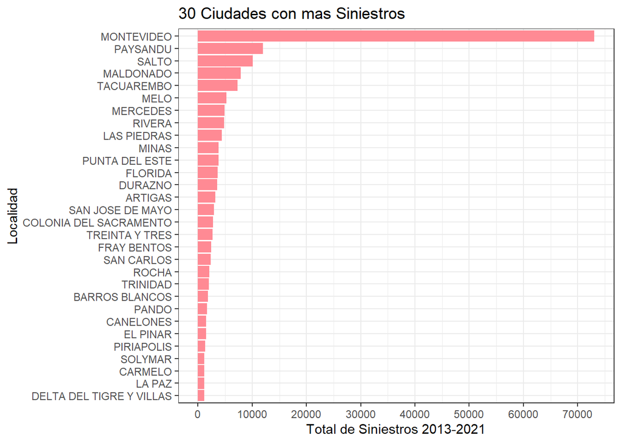

```r
ggplot(Siniestros_Ciudades_Anual %>%
         group_by(NOMBLOC,) %>%
         summarise(Total = sum(Total)) %>%
         top_n(n=30,Total))+
  geom_bar(aes(y=reorder(NOMBLOC,(Total)),weight=Total),fill = "#FF8A94")+
  labs(title =  "30 Ciudades con mas Siniestros",
       y = "Localidad",
       x = "Total de Siniestros 2013-2021")+
  scale_x_continuous(breaks = seq(0,80000,10000))+
  theme_bw()
```

Si bien el total como se anticipaba iba a ser predominante en la ciudad capital, ahora se presenta el mismo grafico pero en funcion de la poblacion.

Para esto se utilizara el total de siniestros cada 10.000 habitantes para medir la siniestralidad, la cantidad de fallecidos cada 10.000 habitantes para medir la mortalidad y la cantidad de fallecidos cada 100 siniestros para medir la gravedad de los siniestros.

Calculo de tasas:

```r
Siniestros_Ciudades_Total <- Siniestros_Ciudades %>%
  st_set_geometry(NULL) %>%
  group_by(NOMBLOC) %>%
  summarise(Total = n())
```

```r
Ciudades <- left_join(Ciudades,Siniestros_Ciudades_Total,by = "NOMBLOC")

Ciudades <- Ciudades %>%
  rename(Habitantes = Total.x,
         Siniestros = Total.y)
```

```r
Ciudades <- Ciudades %>%
  mutate(Siniestros_10000_hab = Siniestros/(Habitantes/10000))
```

```r
Personas_Gravedad <- Personas %>%
  st_set_geometry(NULL) %>%
  mutate(anio = format(floor_date(Fecha,"year"),"%Y")) %>%
  mutate(Mes = floor_date(Fecha,"month")) %>%
  group_by(Gravedad,
           anio) %>%
  summarise(Total = n())
```

```r
Personas_Ciudad_Total <- Personas %>%
  st_set_geometry(NULL) %>%
  mutate(Gravedad_Agrupado = if_else(Gravedad == "FALLECIDO EN CENTRO DE ASISTENCIA" | Gravedad == "FALLECIDO EN EL LUGAR","FATAL",Gravedad)) %>%
  filter(Gravedad_Agrupado == "FATAL") %>%
  group_by(NOMBLOC) %>%
  summarise(Total = n())
```

```r
Ciudades <- left_join(Ciudades,Personas_Ciudad_Total,by = "NOMBLOC")
```

```r
Ciudades <- Ciudades %>%
  mutate_all(~replace(., is.na(.), 0)) %>%
  rename(Fallecidos = Total)
```

```r
Ciudades <- Ciudades %>%
  mutate(Fallecidos_10000_hab = Fallecidos/(Habitantes/10000)) %>%
  mutate(Fallecidos_100_siniestros = Fallecidos/(Siniestros/100))
```

Siniestralidad y Mortabilidad Urbana

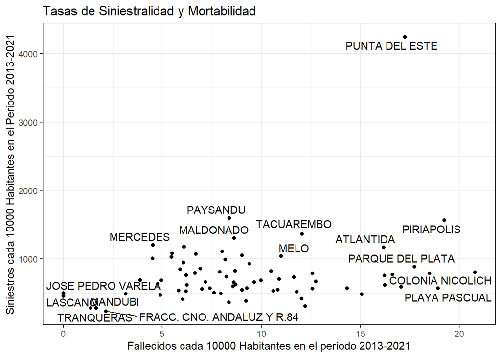

```r
ggplot(Ciudades,aes(x=Fallecidos_10000_hab,y=Siniestros_10000_hab,label = NOMBLOC))+
  geom_point()+
  geom_text_repel()+
  labs(title = "Tasas de Siniestralidad y Mortabilidad",
       y="Siniestros cada 10000 Habitantes en el Periodo 2013-2021",
       x="Fallecidos cada 10000 Habitantes en el periodo 2013-2021")+
  theme_bw()
```

En este grafico se observa la frecuencia de siniestros basadas en la poblacion y la fatalidad de los mismo, aca destaca Punta del Este siendo que la poblacion residente es muy baja pero al ser un lugar turistico la movilidad es mucho mas alta que ciudades de igual medida en otras partes del pais, haciendo que tengan tasas de siniestralidad muy elevadas.

Ahora comparemos estos datos con la gravedad de los siniestros

[figure not shown]

```r
ggplot(Ciudades,aes(x=Fallecidos_10000_hab,y=Fallecidos_100_siniestros,label = NOMBLOC))+
  geom_point()+
  geom_text_repel()+
  labs(title = "Tasas de Siniestralidad y Mortabilidad",
       y="Siniestros cada 10000 Habitantes en el Periodo 2013-2021",
       x="Fallecidos cada 10000 Habitantes en el periodo 2013-2021")+
  theme_bw()
```

Como se puede apreciar ahora Punta del Este se encuentra en la otra parte del cuadro teniedo siniestros mas leves en promedio que otras ciudades mas residenciales o del area metropolitana de montevideo, donde se observa una alta tasa de fallecidos tanto en funcion de la poblacion de como el volumen de siniestros.

Por ultimo, presentaremos la tendencia de la siniestralidad comparando los años 2014 y 2021 para ver que ciudades han mejorado la siniestralidad urbana y donde ha empeorado en este lapso, poniendo fin a nuestro analisis y respondiendo la pregunta planteada al inicio.

Calculo de la tendencia

```r
Siniestros_Ciudades_Evolucion_2014 <- Siniestros_Ciudades %>%
  st_set_geometry(NULL) %>%
  filter(anio == 2014,
         !is.na(NOMBLOC)) %>%
  group_by(NOMBLOC) %>%
  summarise(Total_2014 = n())

Siniestros_Ciudades_Evolucion_2021 <- Siniestros_Ciudades %>%
  st_set_geometry(NULL) %>%
  filter(anio == 2021,
         !is.na(NOMBLOC)) %>%
  group_by(NOMBLOC) %>%
  summarise(Total_2021 = n())

Siniestros_Ciudades_Evolucion <- left_join(Siniestros_Ciudades_Evolucion_2014,Siniestros_Ciudades_Evolucion_2021,by = "NOMBLOC")
```

```r
Ciudades <- left_join(Ciudades,Siniestros_Ciudades_Evolucion,by = "NOMBLOC")
```

```r
Ciudades <- Ciudades %>%
  mutate(Variacion_2021 = ((Total_2021-Total_2014)/Total_2014))
```

Ciudades que mas empeoraron en la cantidad de Siniestros desde 2014, unicamente se muestra aquellas ciudades que tuvieron mas siniestros en 2021 que en 2014.

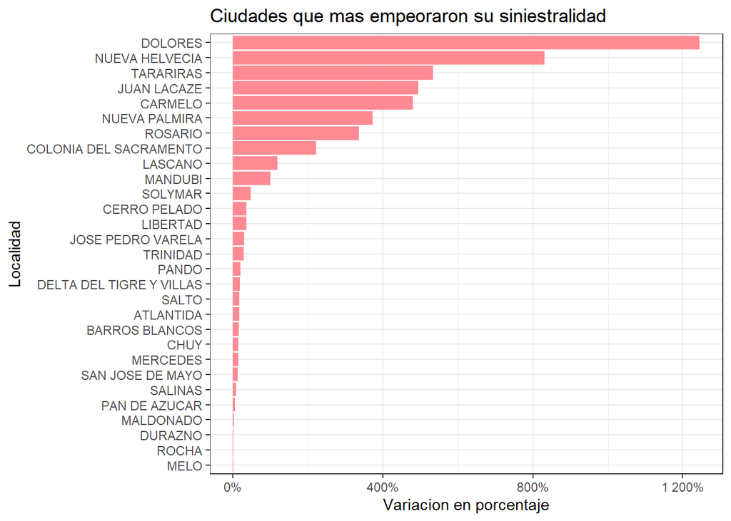

```r
ggplot(Ciudades %>%
         filter(Variacion_2021 > 0))+
  geom_bar(aes(y=reorder(NOMBLOC,(Variacion_2021)),weight=Variacion_2021),fill = "#FF8A94")+
  labs(title = "Ciudades que mas empeoraron su siniestralidad",
       x="Variacion en porcentaje",
       y="Localidad")+
  scale_x_continuous(labels = scales::percent)+
  theme_bw()
```

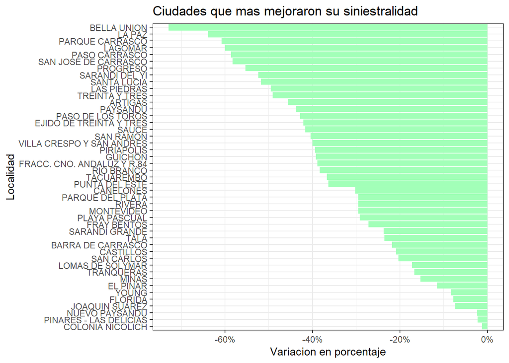

```r
ggplot(Ciudades %>%
         filter(Variacion_2021 < 0))+
  geom_bar(aes(y=reorder(NOMBLOC,(-Variacion_2021)),weight=Variacion_2021),fill = "#A2FFB8")+
  labs(title = "Ciudades que mas mejoraron su siniestralidad",
       x="Variacion en porcentaje",
       y="Localidad")+
  scale_x_continuous(labels = scales::percent)+
  theme_bw()
```

Por ultimo, para mejorar la visualizacion se presenta el siguiente mapa interactivo, donde se pueden observar los datos de estas visualizaciones presentadas previamente.

```r
leaflet(Ciudades) %>%
  addTiles() %>%
  addPolygons(fillColor = Ciudades$Variacion_2021)
```

[interactive chart not shown]